# Casal2 Test Case MPD comparisons for HAK

# 1 HAK comparison of CASAL and Casal2 model configurations

This document compares the results of at least 2 CASAL model configurations (base and at least one sensitivity) and up to 6 Casal2 model configurations (3 BetaDiff and 3 ADOL-C).

The CASAL model sensitivity 1 has a smaller minimisation tolerance value than the CASAL base model (1e-6 vs. 2e-3).

The Casal2 ADOL-C and BetaDiff low tolerance models have a smaller tolerance value than the CASAL base model (1e-6 vs. 2e-3).

## 1.1 HAK model characteristics

The main characteristics of the Test Case HAK (hake) CASAL model are:

- one stock, ages 1 - 30
- one area
- years 1975 - 2018, projection years 2019 - 2022
- two time steps, duration 7 months and 5 months
- recruitment, spawning, aging, maturation, fishing in time step 1
- two stock categories: males and females, with user-provided maturity-at-age ogive
- natural mortality (M) of 0.19
- Beverton-Holt stock-recruitment relationship, with steepness (h) 0.8
- sex-specific Schnute age-length relationship
- sex-specific length-weight relationship ($W = aL^b$)
- ageing error type normal (c = 0.08)
- one fishery with logistic selectivity-at-age
- one survey with logistic selectivity-at-age

Observation data include:

- fishery CPUE index
- fishery proportions-at-age
- survey biomass index
- survey proportions-at-age

Parameters estimated include:

- B0
- catchability (q) for the fishery CPUE index and for the survey index
- fishery and survey selectivity parameters a50 and ato95
- YCS (recruitment deviations)

## 1.3 CASAL and Casal2 model output

```r
source('../../R-functions/report_read_in_CASAL_MPD_files.R')
```

```r
source('../../R-functions/report_read_in_Casal2_MPD_files.R')
```

## 1.4 Tables

Tables of parameter estimates and objective function components for the CASAL and Casal2 model MPD results

CASAL parameter estimates

| rownames | Base_Model | Sensitivity_1 | Percent_Diff |
| --- | --- | --- | --- |
| q[cpue].q | 0.00003 | 0.00003 | 0.000 |
| q[subaTANqA].q | 0.03770 | 0.03770 | 0.000 |
| initialization.B0 | 53980.00000 | 53970.00000 | 0.019 |
| relative_abundance[CPUE].cv_process_error | 0.18650 | 0.18650 | 0.000 |
| recruitment.YCS1 | 0.22050 | 0.22060 | -0.045 |
| recruitment.YCS2 | 0.25550 | 0.25540 | 0.039 |
| recruitment.YCS3 | 0.33330 | 0.33290 | 0.120 |
| recruitment.YCS4 | 0.52930 | 0.52920 | 0.019 |
| recruitment.YCS5 | 0.99260 | 0.99310 | -0.050 |
| recruitment.YCS6 | 0.45120 | 0.45120 | 0.000 |
| recruitment.YCS7 | 2.39300 | 2.39300 | 0.000 |
| recruitment.YCS8 | 0.26930 | 0.26920 | 0.037 |
| recruitment.YCS9 | 0.25740 | 0.25750 | -0.039 |
| recruitment.YCS10 | 0.39650 | 0.39660 | -0.025 |
| recruitment.YCS11 | 0.28070 | 0.28070 | 0.000 |
| recruitment.YCS12 | 0.18880 | 0.18880 | 0.000 |
| recruitment.YCS13 | 0.17060 | 0.17060 | 0.000 |
| recruitment.YCS14 | 0.22170 | 0.22180 | -0.045 |
| recruitment.YCS15 | 0.21300 | 0.21300 | 0.000 |
| recruitment.YCS16 | 0.26520 | 0.26520 | 0.000 |
| recruitment.YCS17 | 0.37740 | 0.37740 | 0.000 |
| recruitment.YCS18 | 0.42920 | 0.42930 | -0.023 |
| recruitment.YCS19 | 0.42380 | 0.42380 | 0.000 |
| recruitment.YCS20 | 0.33890 | 0.33880 | 0.030 |
| recruitment.YCS21 | 0.34620 | 0.34630 | -0.029 |
| recruitment.YCS22 | 0.40100 | 0.40100 | 0.000 |
| recruitment.YCS23 | 0.35060 | 0.35060 | 0.000 |
| recruitment.YCS24 | 0.34050 | 0.34050 | 0.000 |
| recruitment.YCS25 | 0.37120 | 0.37130 | -0.027 |
| recruitment.YCS26 | 0.30060 | 0.30060 | 0.000 |
| recruitment.YCS27 | 0.20090 | 0.20100 | -0.050 |
| recruitment.YCS28 | 0.21080 | 0.21070 | 0.047 |
| recruitment.YCS29 | 0.18550 | 0.18550 | 0.000 |
| recruitment.YCS30 | 0.23530 | 0.23530 | 0.000 |
| recruitment.YCS31 | 0.30030 | 0.30040 | -0.033 |
| recruitment.YCS32 | 0.33160 | 0.33160 | 0.000 |
| recruitment.YCS33 | 0.33130 | 0.33130 | 0.000 |
| recruitment.YCS34 | 0.27620 | 0.27620 | 0.000 |
| recruitment.YCS35 | 0.24590 | 0.24590 | 0.000 |
| recruitment.YCS36 | 0.23790 | 0.23790 | 0.000 |
| recruitment.YCS37 | 0.20480 | 0.20490 | -0.049 |
| recruitment.YCS38 | 0.19030 | 0.19040 | -0.053 |
| recruitment.YCS39 | 0.22450 | 0.22450 | 0.000 |
| recruitment.YCS40 | 0.17620 | 0.17630 | -0.057 |
| recruitment.YCS41 | 0.28120 | 0.28190 | -0.249 |
| recruitment.YCS42 | 0.30480 | 0.30420 | 0.197 |
| recruitment.YCS43 | 0.30390 | 0.30440 | -0.165 |
| recruitment.YCS44 | 1.00000 | 1.00000 | 0.000 |
| selectivity[subaTANselA].all1 | 3.03500 | 3.03500 | 0.000 |
| selectivity[subaTANselA].all2 | 0.10530 | 0.10530 | 0.000 |
| selectivity[subaFsel].all1 | 6.99500 | 6.99500 | 0.000 |
| selectivity[subaFsel].all2 | 2.70700 | 2.70700 | 0.000 |

Casal2 parameter estimates

| rownames | betadiff_casal_flags_on | betadiff_casal_flags_off | betadiff_casal_flags_on_low_tol | adolc_casal_flags_on | adolc_casal_flags_off | adolc_casal_flags_on_low_tol |
| --- | --- | --- | --- | --- | --- | --- |
| process[Recruitment].b0 | 53971.10000 | 53971.10000 | 53971.60000 | 53980.50000 | 53980.50000 | 53971.60000 |
| catchability[CPUEq].q | 0.00003 | 0.00003 | 0.00003 | 0.00003 | 0.00003 | 0.00003 |
| catchability[subaTANqA].q | 0.03770 | 0.03770 | 0.03770 | 0.03770 | 0.03770 | 0.03770 |
| selectivity[subaFsel].a50 | 6.99702 | 6.99702 | 6.99583 | 6.99529 | 6.99529 | 6.99583 |
| selectivity[subaFsel].ato95 | 2.70985 | 2.70985 | 2.70805 | 2.70696 | 2.70696 | 2.70805 |
| selectivity[subaTANselA].a50 | 3.03406 | 3.03406 | 3.03406 | 3.03383 | 3.03383 | 3.03383 |
| selectivity[subaTANselA].ato95 | 0.10110 | 0.10110 | 0.10110 | 0.10039 | 0.10039 | 0.10039 |
| observation[CPUE].process_error | 0.18657 | 0.18657 | 0.18649 | 0.18651 | 0.18651 | 0.18649 |
| process[Recruitment].recruitment_multipliers{1975} | 0.22118 | 0.22118 | 0.22060 | 0.22018 | 0.22018 | 0.22060 |
| process[Recruitment].recruitment_multipliers{1976} | 0.25534 | 0.25534 | 0.25534 | 0.25512 | 0.25512 | 0.25534 |
| process[Recruitment].recruitment_multipliers{1977} | 0.33340 | 0.33340 | 0.33312 | 0.33461 | 0.33461 | 0.33312 |
| process[Recruitment].recruitment_multipliers{1978} | 0.53695 | 0.53695 | 0.53131 | 0.52951 | 0.52951 | 0.53131 |
| process[Recruitment].recruitment_multipliers{1979} | 0.97692 | 0.97692 | 0.98817 | 0.99153 | 0.99153 | 0.98817 |
| process[Recruitment].recruitment_multipliers{1980} | 0.45778 | 0.45778 | 0.45379 | 0.45354 | 0.45354 | 0.45379 |
| process[Recruitment].recruitment_multipliers{1981} | 2.38950 | 2.38950 | 2.39155 | 2.39208 | 2.39208 | 2.39155 |
| process[Recruitment].recruitment_multipliers{1982} | 0.26791 | 0.26791 | 0.26921 | 0.26942 | 0.26942 | 0.26921 |
| process[Recruitment].recruitment_multipliers{1983} | 0.25726 | 0.25726 | 0.25749 | 0.25735 | 0.25735 | 0.25749 |
| process[Recruitment].recruitment_multipliers{1984} | 0.39551 | 0.39551 | 0.39605 | 0.39554 | 0.39554 | 0.39605 |
| process[Recruitment].recruitment_multipliers{1985} | 0.28075 | 0.28075 | 0.28098 | 0.28171 | 0.28171 | 0.28098 |
| process[Recruitment].recruitment_multipliers{1986} | 0.18878 | 0.18878 | 0.18870 | 0.18868 | 0.18868 | 0.18870 |
| process[Recruitment].recruitment_multipliers{1987} | 0.17031 | 0.17031 | 0.17051 | 0.17041 | 0.17041 | 0.17051 |
| process[Recruitment].recruitment_multipliers{1988} | 0.22136 | 0.22136 | 0.22180 | 0.22191 | 0.22191 | 0.22180 |
| process[Recruitment].recruitment_multipliers{1989} | 0.21307 | 0.21307 | 0.21291 | 0.21300 | 0.21300 | 0.21291 |
| process[Recruitment].recruitment_multipliers{1990} | 0.26451 | 0.26451 | 0.26515 | 0.26521 | 0.26521 | 0.26515 |
| process[Recruitment].recruitment_multipliers{1991} | 0.37673 | 0.37673 | 0.37722 | 0.37683 | 0.37683 | 0.37722 |
| process[Recruitment].recruitment_multipliers{1992} | 0.42850 | 0.42850 | 0.42968 | 0.43071 | 0.43071 | 0.42968 |
| process[Recruitment].recruitment_multipliers{1993} | 0.42364 | 0.42364 | 0.42336 | 0.42268 | 0.42268 | 0.42336 |
| process[Recruitment].recruitment_multipliers{1994} | 0.33853 | 0.33853 | 0.33895 | 0.33926 | 0.33926 | 0.33895 |
| process[Recruitment].recruitment_multipliers{1995} | 0.34544 | 0.34544 | 0.34626 | 0.34639 | 0.34639 | 0.34626 |
| process[Recruitment].recruitment_multipliers{1996} | 0.40089 | 0.40089 | 0.40086 | 0.40098 | 0.40098 | 0.40086 |
| process[Recruitment].recruitment_multipliers{1997} | 0.35002 | 0.35002 | 0.35062 | 0.35066 | 0.35066 | 0.35062 |
| process[Recruitment].recruitment_multipliers{1998} | 0.34008 | 0.34008 | 0.34043 | 0.34052 | 0.34052 | 0.34043 |
| process[Recruitment].recruitment_multipliers{1999} | 0.37075 | 0.37075 | 0.37119 | 0.37132 | 0.37132 | 0.37119 |
| process[Recruitment].recruitment_multipliers{2000} | 0.30019 | 0.30019 | 0.30049 | 0.30058 | 0.30058 | 0.30049 |
| process[Recruitment].recruitment_multipliers{2001} | 0.20063 | 0.20063 | 0.20099 | 0.20106 | 0.20106 | 0.20099 |
| process[Recruitment].recruitment_multipliers{2002} | 0.21058 | 0.21058 | 0.21069 | 0.21076 | 0.21076 | 0.21069 |
| process[Recruitment].recruitment_multipliers{2003} | 0.18514 | 0.18514 | 0.18547 | 0.18554 | 0.18554 | 0.18547 |
| process[Recruitment].recruitment_multipliers{2004} | 0.23505 | 0.23505 | 0.23524 | 0.23530 | 0.23530 | 0.23524 |
| process[Recruitment].recruitment_multipliers{2005} | 0.30000 | 0.30000 | 0.30036 | 0.30047 | 0.30047 | 0.30036 |
| process[Recruitment].recruitment_multipliers{2006} | 0.33124 | 0.33124 | 0.33155 | 0.33164 | 0.33164 | 0.33155 |
| process[Recruitment].recruitment_multipliers{2007} | 0.33092 | 0.33092 | 0.33128 | 0.33139 | 0.33139 | 0.33128 |
| process[Recruitment].recruitment_multipliers{2008} | 0.27601 | 0.27601 | 0.27611 | 0.27622 | 0.27622 | 0.27611 |
| process[Recruitment].recruitment_multipliers{2009} | 0.24564 | 0.24564 | 0.24593 | 0.24600 | 0.24600 | 0.24593 |
| process[Recruitment].recruitment_multipliers{2010} | 0.23773 | 0.23773 | 0.23792 | 0.23800 | 0.23800 | 0.23792 |
| process[Recruitment].recruitment_multipliers{2011} | 0.20483 | 0.20483 | 0.20479 | 0.20488 | 0.20488 | 0.20479 |
| process[Recruitment].recruitment_multipliers{2012} | 0.19025 | 0.19025 | 0.19039 | 0.19051 | 0.19051 | 0.19039 |
| process[Recruitment].recruitment_multipliers{2013} | 0.22454 | 0.22454 | 0.22452 | 0.22453 | 0.22453 | 0.22452 |
| process[Recruitment].recruitment_multipliers{2014} | 0.17588 | 0.17588 | 0.17625 | 0.17649 | 0.17649 | 0.17625 |
| process[Recruitment].recruitment_multipliers{2015} | 0.28275 | 0.28275 | 0.28185 | 0.28103 | 0.28103 | 0.28185 |
| process[Recruitment].recruitment_multipliers{2016} | 0.30581 | 0.30581 | 0.30425 | 0.33310 | 0.33310 | 0.30425 |
| process[Recruitment].recruitment_multipliers{2017} | 0.30213 | 0.30213 | 0.30437 | 0.27738 | 0.27738 | 0.30437 |

Casal2 parameter estimates: Percent Difference from betadiff_casal_flags_on

| rownames | betadiff_casal_flags_on | betadiff_casal_flags_off | betadiff_casal_flags_on_low_tol | adolc_casal_flags_on | adolc_casal_flags_off | adolc_casal_flags_on_low_tol |
| --- | --- | --- | --- | --- | --- | --- |
| process[Recruitment].b0 | 0.000 | 0.000 | -0.001 | -0.017 | -0.017 | -0.001 |
| catchability[CPUEq].q | 0.000 | 0.000 | 0.037 | 0.060 | 0.060 | 0.037 |
| catchability[subaTANqA].q | 0.000 | 0.000 | -0.012 | 0.014 | 0.014 | -0.012 |
| selectivity[subaFsel].a50 | 0.000 | 0.000 | 0.017 | 0.025 | 0.025 | 0.017 |
| selectivity[subaFsel].ato95 | 0.000 | 0.000 | 0.066 | 0.107 | 0.107 | 0.066 |
| selectivity[subaTANselA].a50 | 0.000 | 0.000 | 0.000 | 0.008 | 0.008 | 0.008 |
| selectivity[subaTANselA].ato95 | 0.000 | 0.000 | -0.003 | 0.701 | 0.701 | 0.700 |
| observation[CPUE].process_error | 0.000 | 0.000 | 0.046 | 0.033 | 0.033 | 0.046 |
| process[Recruitment].recruitment_multipliers{1975} | 0.000 | 0.000 | 0.261 | 0.450 | 0.450 | 0.261 |
| process[Recruitment].recruitment_multipliers{1976} | 0.000 | 0.000 | -0.002 | 0.085 | 0.085 | -0.002 |
| process[Recruitment].recruitment_multipliers{1977} | 0.000 | 0.000 | 0.084 | -0.363 | -0.363 | 0.084 |
| process[Recruitment].recruitment_multipliers{1978} | 0.000 | 0.000 | 1.051 | 1.386 | 1.386 | 1.051 |
| process[Recruitment].recruitment_multipliers{1979} | 0.000 | 0.000 | -1.151 | -1.495 | -1.495 | -1.151 |
| process[Recruitment].recruitment_multipliers{1980} | 0.000 | 0.000 | 0.872 | 0.926 | 0.926 | 0.872 |
| process[Recruitment].recruitment_multipliers{1981} | 0.000 | 0.000 | -0.086 | -0.108 | -0.108 | -0.086 |
| process[Recruitment].recruitment_multipliers{1982} | 0.000 | 0.000 | -0.486 | -0.565 | -0.565 | -0.486 |
| process[Recruitment].recruitment_multipliers{1983} | 0.000 | 0.000 | -0.088 | -0.034 | -0.034 | -0.088 |
| process[Recruitment].recruitment_multipliers{1984} | 0.000 | 0.000 | -0.138 | -0.009 | -0.009 | -0.138 |
| process[Recruitment].recruitment_multipliers{1985} | 0.000 | 0.000 | -0.083 | -0.341 | -0.341 | -0.083 |
| process[Recruitment].recruitment_multipliers{1986} | 0.000 | 0.000 | 0.040 | 0.054 | 0.054 | 0.040 |
| process[Recruitment].recruitment_multipliers{1987} | 0.000 | 0.000 | -0.119 | -0.060 | -0.060 | -0.119 |
| process[Recruitment].recruitment_multipliers{1988} | 0.000 | 0.000 | -0.199 | -0.244 | -0.244 | -0.199 |
| process[Recruitment].recruitment_multipliers{1989} | 0.000 | 0.000 | 0.072 | 0.031 | 0.031 | 0.072 |
| process[Recruitment].recruitment_multipliers{1990} | 0.000 | 0.000 | -0.239 | -0.262 | -0.262 | -0.239 |
| process[Recruitment].recruitment_multipliers{1991} | 0.000 | 0.000 | -0.130 | -0.027 | -0.027 | -0.130 |
| process[Recruitment].recruitment_multipliers{1992} | 0.000 | 0.000 | -0.277 | -0.516 | -0.516 | -0.277 |
| process[Recruitment].recruitment_multipliers{1993} | 0.000 | 0.000 | 0.066 | 0.227 | 0.227 | 0.066 |
| process[Recruitment].recruitment_multipliers{1994} | 0.000 | 0.000 | -0.123 | -0.214 | -0.214 | -0.123 |
| process[Recruitment].recruitment_multipliers{1995} | 0.000 | 0.000 | -0.239 | -0.275 | -0.275 | -0.239 |
| process[Recruitment].recruitment_multipliers{1996} | 0.000 | 0.000 | 0.005 | -0.024 | -0.024 | 0.005 |
| process[Recruitment].recruitment_multipliers{1997} | 0.000 | 0.000 | -0.171 | -0.184 | -0.184 | -0.171 |
| process[Recruitment].recruitment_multipliers{1998} | 0.000 | 0.000 | -0.105 | -0.131 | -0.131 | -0.105 |
| process[Recruitment].recruitment_multipliers{1999} | 0.000 | 0.000 | -0.118 | -0.153 | -0.153 | -0.118 |
| process[Recruitment].recruitment_multipliers{2000} | 0.000 | 0.000 | -0.098 | -0.127 | -0.127 | -0.098 |
| process[Recruitment].recruitment_multipliers{2001} | 0.000 | 0.000 | -0.180 | -0.212 | -0.212 | -0.180 |
| process[Recruitment].recruitment_multipliers{2002} | 0.000 | 0.000 | -0.052 | -0.085 | -0.085 | -0.052 |
| process[Recruitment].recruitment_multipliers{2003} | 0.000 | 0.000 | -0.180 | -0.214 | -0.214 | -0.180 |
| process[Recruitment].recruitment_multipliers{2004} | 0.000 | 0.000 | -0.080 | -0.106 | -0.106 | -0.080 |
| process[Recruitment].recruitment_multipliers{2005} | 0.000 | 0.000 | -0.120 | -0.154 | -0.154 | -0.120 |
| process[Recruitment].recruitment_multipliers{2006} | 0.000 | 0.000 | -0.094 | -0.122 | -0.122 | -0.094 |
| process[Recruitment].recruitment_multipliers{2007} | 0.000 | 0.000 | -0.110 | -0.142 | -0.142 | -0.110 |
| process[Recruitment].recruitment_multipliers{2008} | 0.000 | 0.000 | -0.039 | -0.079 | -0.079 | -0.039 |
| process[Recruitment].recruitment_multipliers{2009} | 0.000 | 0.000 | -0.120 | -0.147 | -0.147 | -0.120 |
| process[Recruitment].recruitment_multipliers{2010} | 0.000 | 0.000 | -0.082 | -0.115 | -0.115 | -0.082 |
| process[Recruitment].recruitment_multipliers{2011} | 0.000 | 0.000 | 0.020 | -0.026 | -0.026 | 0.020 |
| process[Recruitment].recruitment_multipliers{2012} | 0.000 | 0.000 | -0.077 | -0.136 | -0.136 | -0.077 |
| process[Recruitment].recruitment_multipliers{2013} | 0.000 | 0.000 | 0.011 | 0.004 | 0.004 | 0.011 |
| process[Recruitment].recruitment_multipliers{2014} | 0.000 | 0.000 | -0.209 | -0.343 | -0.343 | -0.209 |
| process[Recruitment].recruitment_multipliers{2015} | 0.000 | 0.000 | 0.319 | 0.609 | 0.609 | 0.319 |
| process[Recruitment].recruitment_multipliers{2016} | 0.000 | 0.000 | 0.511 | -8.922 | -8.922 | 0.511 |
| process[Recruitment].recruitment_multipliers{2017} | 0.000 | 0.000 | -0.742 | 8.193 | 8.193 | -0.742 |

CASAL objective function component values

| Component | Base_Model | Sensitivity_1 |
| --- | --- | --- |
| CPUE | -30.370 | -30.370 |
| subaTANbiomassDEC | -15.230 | -15.230 |
| subaTANageDEC | 388.900 | 388.900 |
| subaOBSage | 397.100 | 397.100 |
| prior_on_q[cpue].q | -10.580 | -10.580 |
| prior_on_q[subaTANqA].q | -1.786 | -1.786 |
| prior_on_initialization.B0 | 10.900 | 10.900 |
| prior_on_relative_abundance[CPUE].cv_process_error | -1.679 | -1.679 |
| prior_on_recruitment.YCS | -28.230 | -28.230 |
| prior_on_selectivity[subaTANselA].all | 0.000 | 0.000 |
| prior_on_selectivity[subaFsel].all | 0.000 | 0.000 |
| subaCatchMustBeTaken | 0.000 | 0.000 |
| Total | 709.100 | 709.100 |

Casal2 objective function component values

| rownames | betadiff_casal_flags_on | betadiff_casal_flags_off | betadiff_casal_flags_on_low_tol | adolc_casal_flags_on | adolc_casal_flags_off | adolc_casal_flags_on_low_tol |
| --- | --- | --- | --- | --- | --- | --- |
| observation->subaTANbiomassDEC->1992 | 0.431 | 0.431 | 0.431 | 0.431 | 0.431 | 0.431 |
| observation->subaTANbiomassDEC->1993 | -0.287 | -0.287 | -0.286 | -0.287 | -0.287 | -0.286 |
| observation->subaTANbiomassDEC->1994 | -1.467 | -1.467 | -1.466 | -1.466 | -1.466 | -1.466 |
| observation->subaTANbiomassDEC->2001 | -1.138 | -1.138 | -1.139 | -1.138 | -1.138 | -1.139 |
| observation->subaTANbiomassDEC->2002 | -1.282 | -1.282 | -1.282 | -1.282 | -1.282 | -1.282 |
| observation->subaTANbiomassDEC->2003 | -1.111 | -1.111 | -1.110 | -1.111 | -1.111 | -1.110 |
| observation->subaTANbiomassDEC->2004 | -1.035 | -1.035 | -1.034 | -1.034 | -1.034 | -1.034 |
| observation->subaTANbiomassDEC->2005 | -1.190 | -1.190 | -1.190 | -1.190 | -1.190 | -1.190 |
| observation->subaTANbiomassDEC->2006 | -1.059 | -1.059 | -1.058 | -1.058 | -1.058 | -1.058 |
| observation->subaTANbiomassDEC->2007 | -1.270 | -1.270 | -1.269 | -1.269 | -1.269 | -1.269 |
| observation->subaTANbiomassDEC->2008 | -0.156 | -0.156 | -0.159 | -0.158 | -0.158 | -0.159 |
| observation->subaTANbiomassDEC->2009 | -0.805 | -0.805 | -0.807 | -0.806 | -0.806 | -0.807 |
| observation->subaTANbiomassDEC->2010 | -1.179 | -1.179 | -1.178 | -1.179 | -1.179 | -1.178 |
| observation->subaTANbiomassDEC->2012 | -0.947 | -0.947 | -0.948 | -0.948 | -0.948 | -0.948 |
| observation->subaTANbiomassDEC->2013 | -0.935 | -0.935 | -0.936 | -0.936 | -0.936 | -0.936 |
| observation->subaTANbiomassDEC->2015 | -1.163 | -1.163 | -1.163 | -1.163 | -1.163 | -1.163 |
| observation->subaTANbiomassDEC->2017 | -0.636 | -0.636 | -0.635 | -0.636 | -0.636 | -0.635 |
| observation->subaTANageDEC->1990 | 16.567 | 16.567 | 16.566 | 16.564 | 16.564 | 16.566 |
| observation->subaTANageDEC->1992 | 19.099 | 19.099 | 19.096 | 19.096 | 19.096 | 19.096 |
| observation->subaTANageDEC->1993 | 22.349 | 22.349 | 22.351 | 22.347 | 22.347 | 22.351 |
| observation->subaTANageDEC->1994 | 27.482 | 27.482 | 27.486 | 27.484 | 27.484 | 27.486 |
| observation->subaTANageDEC->2001 | 25.961 | 25.961 | 25.958 | 25.956 | 25.956 | 25.958 |
| observation->subaTANageDEC->2002 | 26.347 | 26.347 | 26.346 | 26.345 | 26.345 | 26.346 |
| observation->subaTANageDEC->2003 | 25.672 | 25.672 | 25.672 | 25.672 | 25.672 | 25.672 |
| observation->subaTANageDEC->2004 | 19.470 | 19.470 | 19.469 | 19.470 | 19.470 | 19.469 |
| observation->subaTANageDEC->2005 | 19.259 | 19.259 | 19.259 | 19.259 | 19.259 | 19.259 |
| observation->subaTANageDEC->2006 | 20.373 | 20.373 | 20.373 | 20.373 | 20.373 | 20.373 |
| observation->subaTANageDEC->2007 | 24.451 | 24.451 | 24.452 | 24.452 | 24.452 | 24.452 |
| observation->subaTANageDEC->2008 | 23.587 | 23.587 | 23.587 | 23.587 | 23.587 | 23.587 |
| observation->subaTANageDEC->2009 | 24.425 | 24.425 | 24.427 | 24.427 | 24.427 | 24.427 |

[output cut: 109 more lines]

```
## [1] "CASAL base model convergence information"
## [1] "Minimiser achieved convergence after 243 quasi-Newton iterations using 286 objective function evaluations"
## [1] ""
## [1] "CASAL sensitivity 1 model convergence information"
## [1] "Minimiser convergence threshold: 1e-06"
## [2] "Minimiser achieved convergence after 252 quasi-Newton iterations using 295 objective function evaluations"
## [1] ""
## [1] "Casal2 betadiff_casal_flags_on model convergence information"
## [1] "fmm: have converged: t = 0.000614225 f = 709.014"
## [2] "Successful convergence in optimise"
## [1] ""
## [1] "Casal2 betadiff_casal_flags_off model convergence information"
## [1] "fmm: have converged: t = 0.000614225 f = 709.014"
## [2] "Successful convergence in optimise"
## [1] ""
## [1] "Casal2 betadiff_casal_flags_on_low_tol model convergence information"
## [1] "fmm: have converged: t = 1.0503e-07 f = 709.014"
## [2] "Successful convergence in optimise"
## [1] ""
## [1] "Casal2 adolc_casal_flags_on model convergence information"
## character(0)
## [1] ""
## [1] "Casal2 adolc_casal_flags_off model convergence information"
## character(0)
## [1] ""
## [1] "Casal2 adolc_casal_flags_on_low_tol model convergence information"
## character(0)
```

```
## [1] "CASAL model warnings"
##                         parameter  estimate lower.bound upper.bound
## 1                       q[cpue].q 2.534e-05       1e-08         0.1
## 2 selectivity[subaTANselA].all[2]    0.1053         0.1          50
## [1] ""
## [1] "CASAL sensitivity 1 model warnings"
##                         parameter  estimate lower.bound upper.bound
## 1                       q[cpue].q 2.534e-05       1e-08         0.1
## 2 selectivity[subaTANselA].all[2]    0.1053         0.1          50
## [1] ""
## [1] "Casal2 betadiff_casal_flags_on model warnings"
##  [1] "obs sum total (1.0002) for year (1990) doesn't sum to 1.0"
##  [2] "obs sum total (1.0001) for year (1992) doesn't sum to 1.0"
##  [3] "obs sum total (0.9999) for year (1993) doesn't sum to 1.0"
##  [4] "obs sum total (0.9999) for year (1994) doesn't sum to 1.0"
```

[output cut: 210 more lines]

## 1.5 Matching of outputs

Time series comparisons with CASAL base model results

```
## [1] "Catch time series base model comparison for run betadiff_casal_flags_on"
## [1] "Actual catches for fishery match: yes"
## [1] ""
## [1] "Catch time series base model comparison for run betadiff_casal_flags_off"
## [1] "Actual catches for fishery match: yes"
## [1] ""
## [1] "Catch time series base model comparison for run betadiff_casal_flags_on_low_tol"
## [1] "Actual catches for fishery match: yes"
## [1] ""
## [1] "Catch time series base model comparison for run adolc_casal_flags_on"
## [1] "Actual catches for fishery match: yes"
## [1] ""
## [1] "Catch time series base model comparison for run adolc_casal_flags_off"
## [1] "Actual catches for fishery match: yes"
## [1] ""
## [1] "Catch time series base model comparison for run adolc_casal_flags_on_low_tol"
## [1] "Actual catches for fishery match: yes"
## [1] ""
```

## 1.6 Plots

Comparison plots

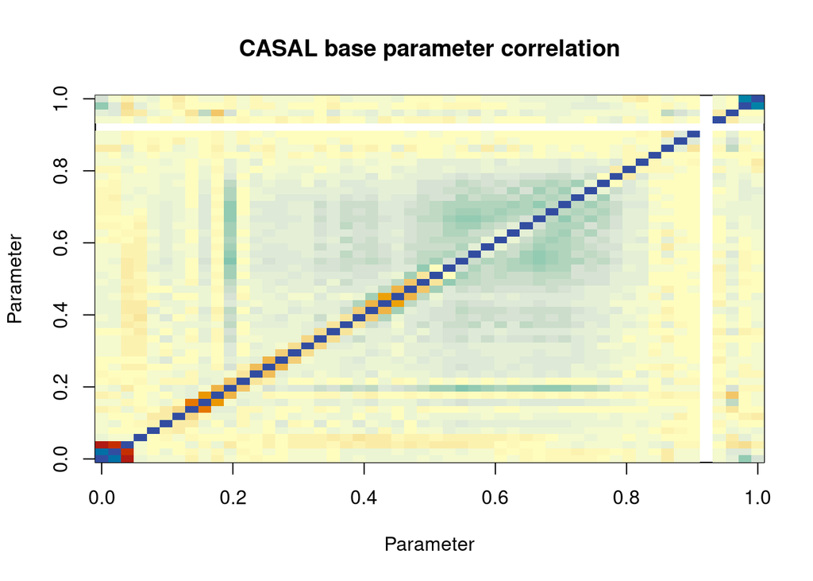

```
## [1] "CASAL base parameter correlation range (excluding 1.0): -0.9256 0.8467"
```

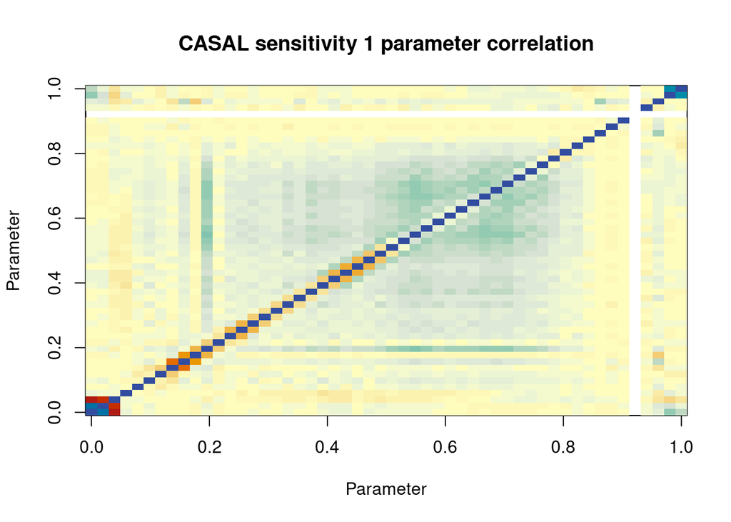

```
## [1] "CASAL sensitivity 1 parameter correlation range (excluding 1.0): -0.9298 0.8509"
```

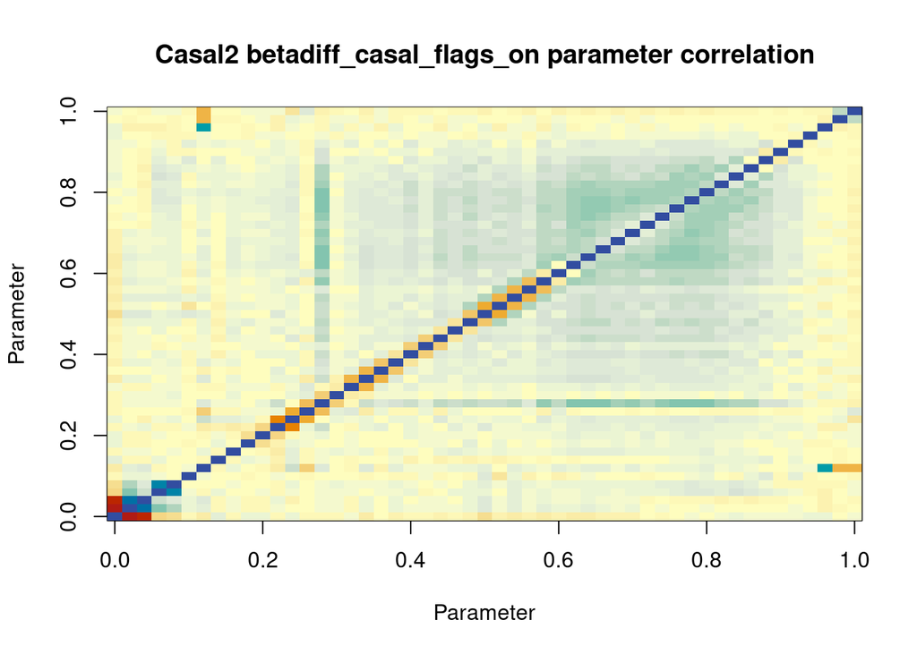

```
## [1] "Casal2 betadiff_casal_flags_on parameter correlation range (excluding 1.0): -0.938514 0.876049"
```

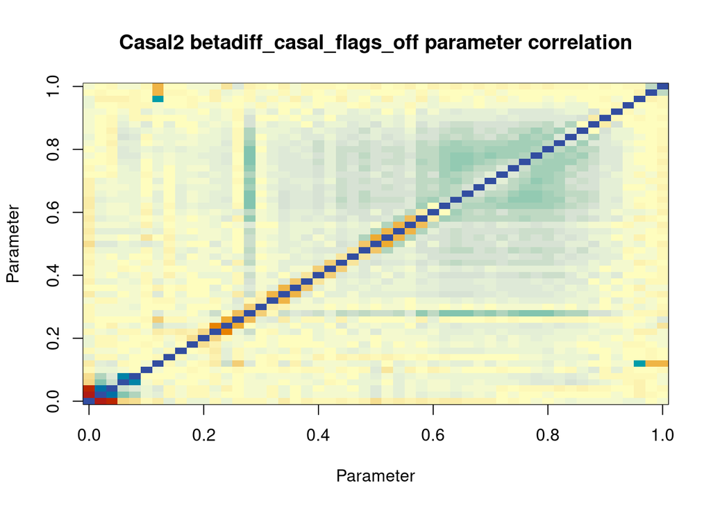

```
## [1] "Casal2 betadiff_casal_flags_off parameter correlation range (excluding 1.0): -0.938514 0.876049"
```

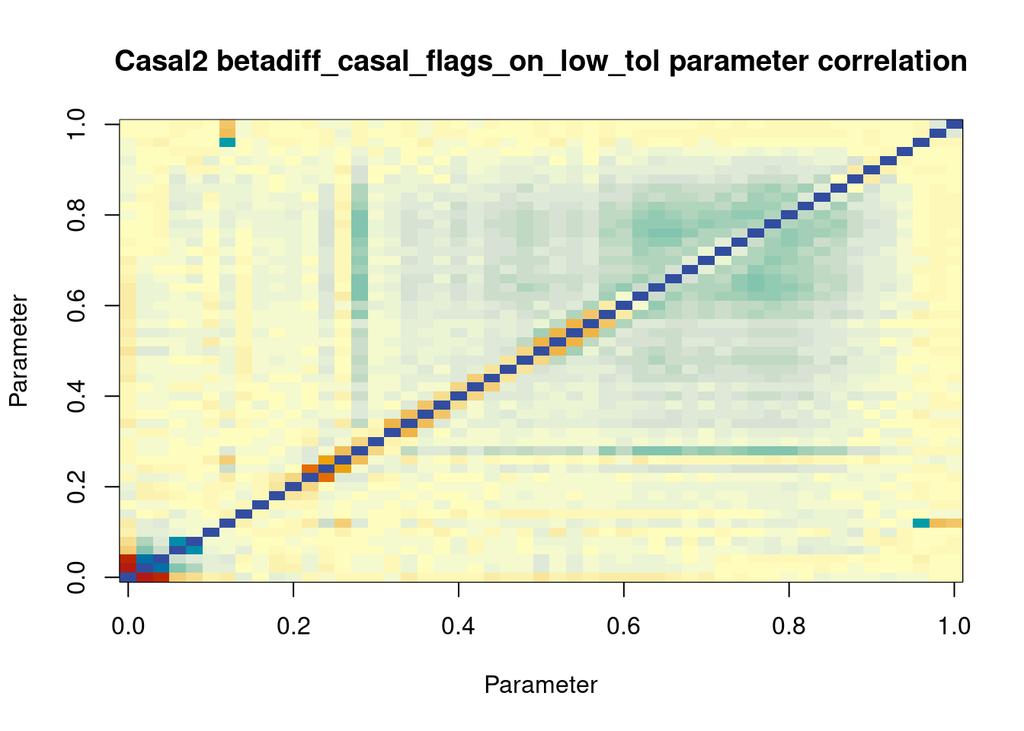

```
## [1] "Casal2 betadiff_casal_flags_on_low_tol parameter correlation range (excluding 1.0): -0.935243 0.870116"
```

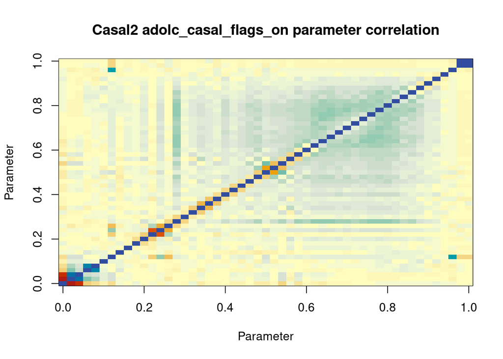

```
## [1] "Casal2 adolc_casal_flags_on parameter correlation range (excluding 1.0): -0.929045 0.983589"
```

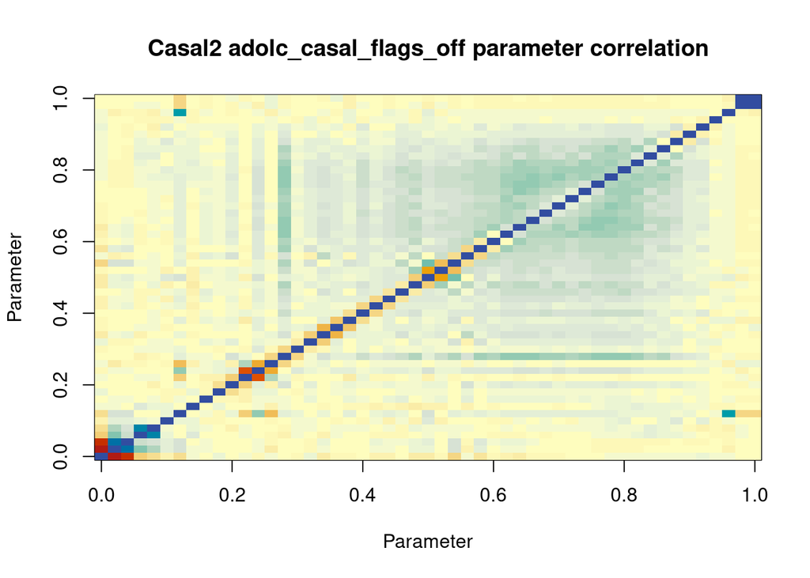

```
## [1] "Casal2 adolc_casal_flags_off parameter correlation range (excluding 1.0): -0.929045 0.983589"
```

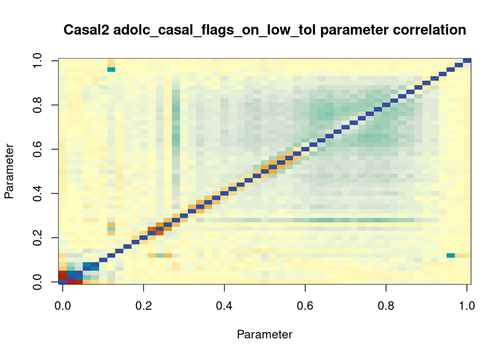

```
## [1] "Casal2 adolc_casal_flags_on_low_tol parameter correlation range (excluding 1.0): -0.931535 0.862842"
```

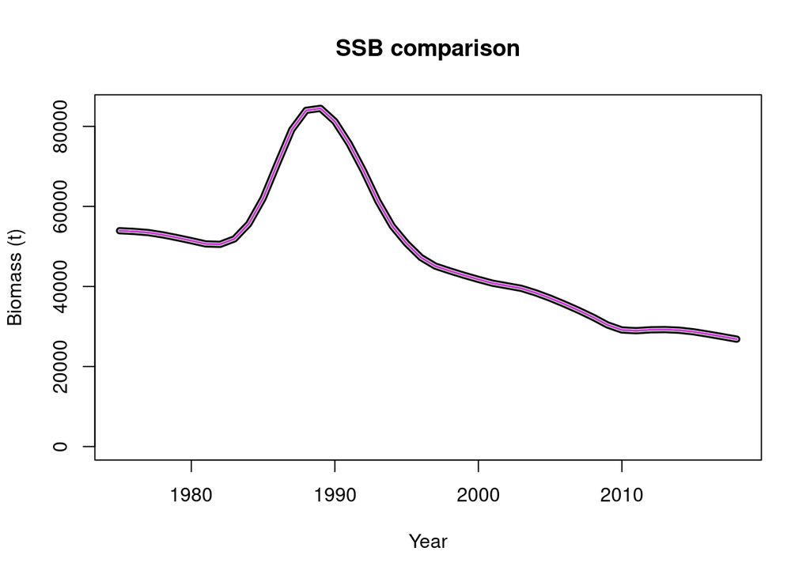

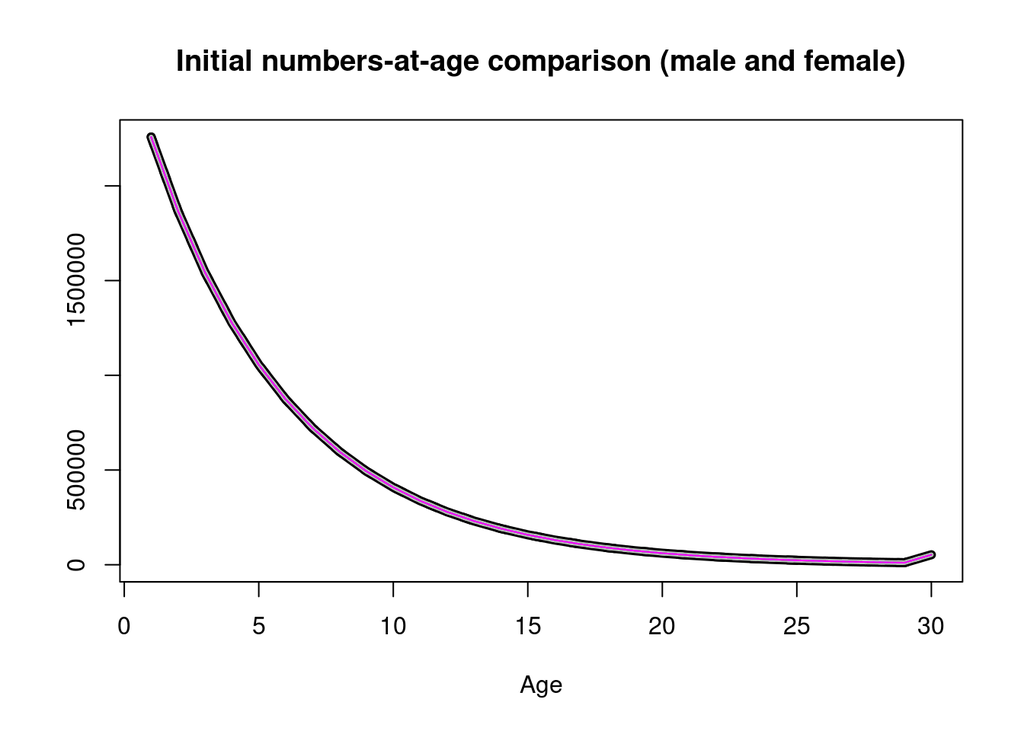

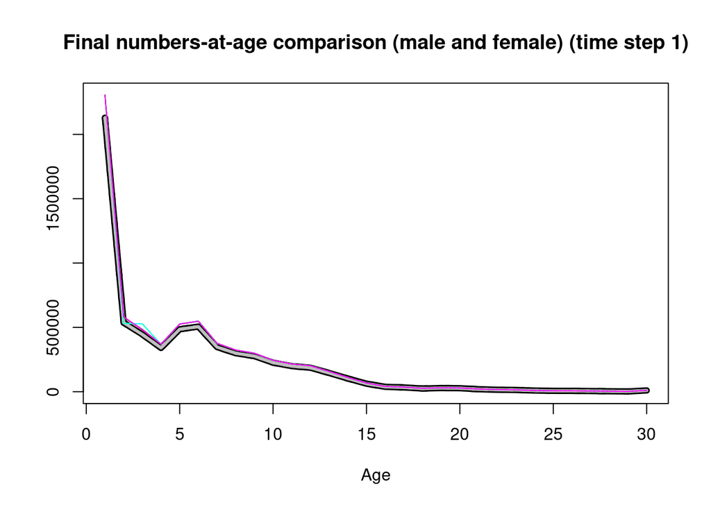

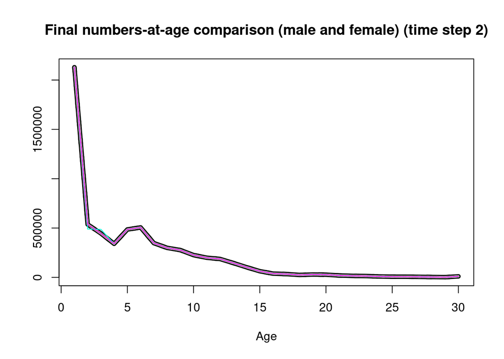

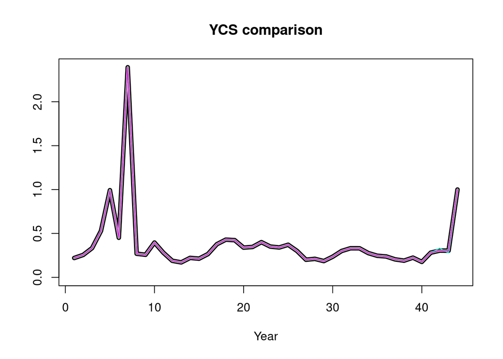

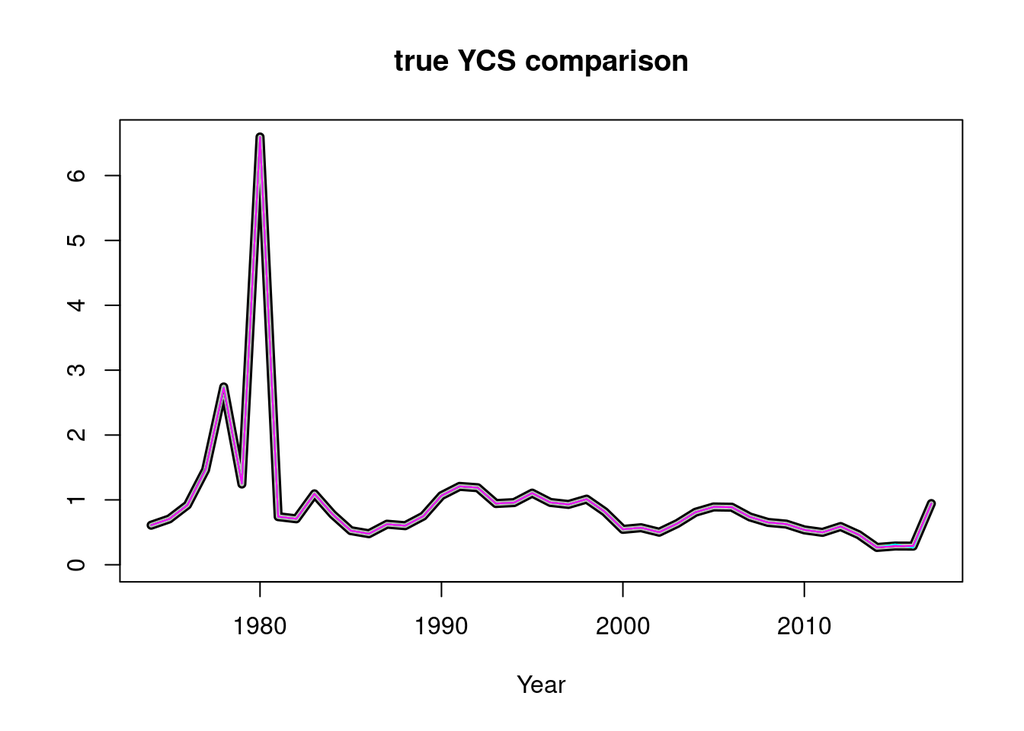

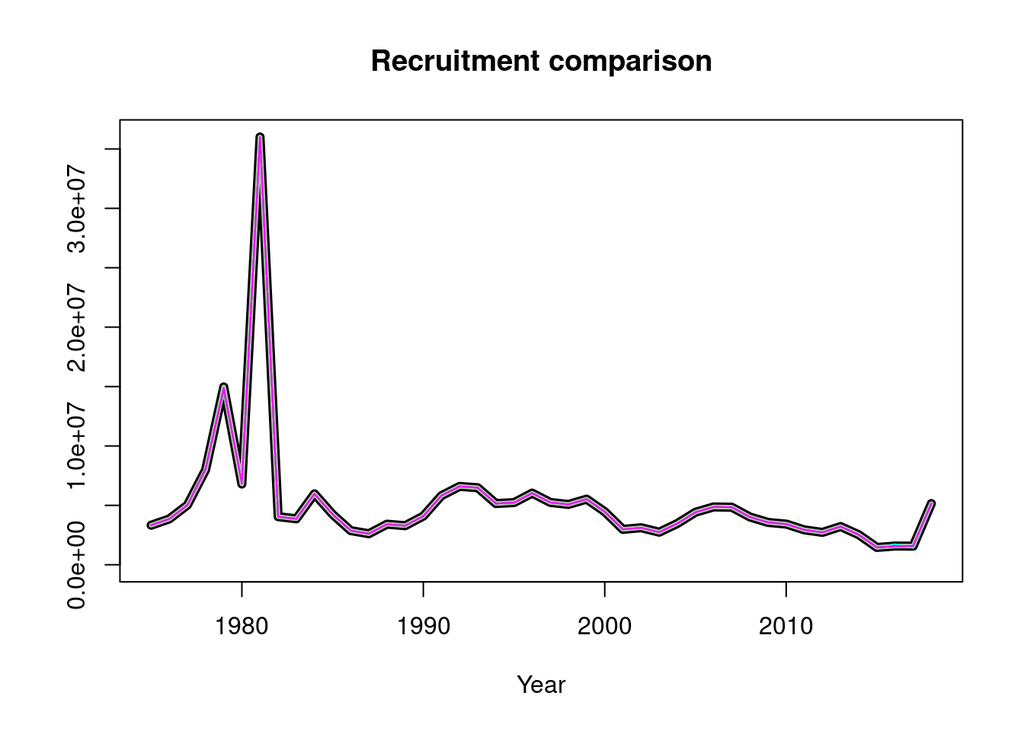

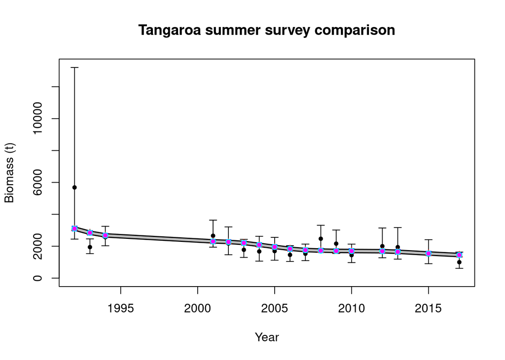

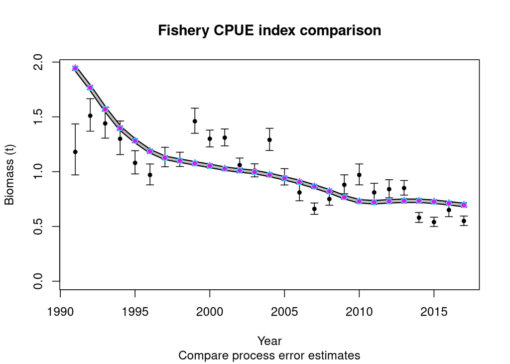

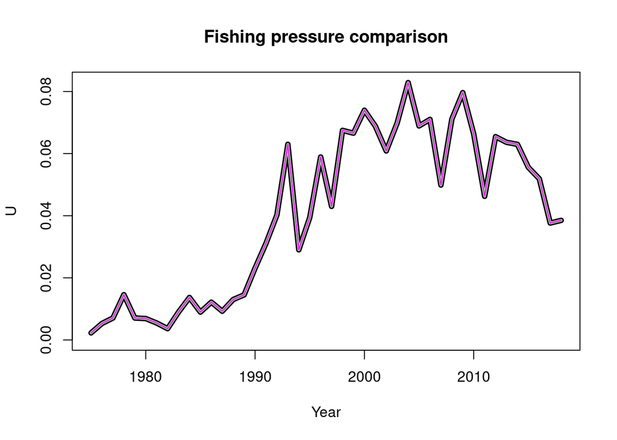

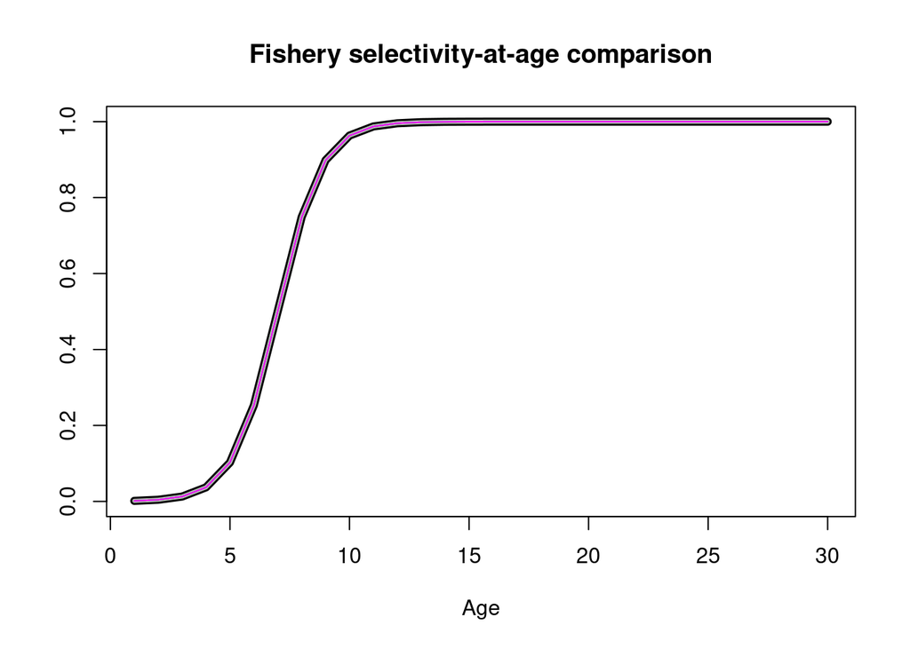

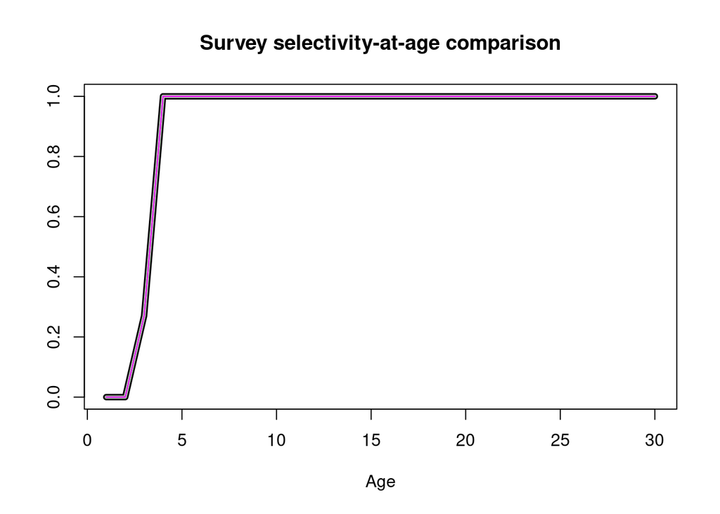